# Tutorial Expectation-Maximization for Gaussian Mixture Models

The goal is to apply EM for multivariate GMMs on the Wine dataset, available in the `pgmm` package.

### Instructions

1. **Implementing the EM**
- Implement from scratch the EM algorithm for a GMM on the variables 2 and 4 of the wine data set.
- Cluster the data and compare your results with k-means.
- To assess the quality of the clustering, you may use the function classError and/or adjustedRandIndex from the Mclust package.
2. **Model selection**
- Try to find a relevant number of clusters using the three methods seen in class: AIC, BIC, and (cross-)validated likelihood.
3. **Towards higher dimensional spaces**
- Try to model more than just two variables of the same data set. Do you find the same clusters, the same number of clusters.

# 1 - Library and dataset imports

#### 1.1. Library imports

```r
# we'll use this package to load the data
#install.packages("pgmm"); install.packages('mvtnorm'); install.packages('mclust')
library(pgmm); library(mvtnorm); library(mclust)
```

### 1.2. Dataset import

Once the package are loaded, we can load the data in the environment.

```r
data(wine)
head(wine)
```

|  | Type | Alcohol | Sugar-free Extract | Fixed Acidity | Tartaric Acid | Malic Acid | Uronic Acids | pH | Ash | Alcalinity of Ash | Potassium | Calcium | Magnesium | Phosphate | Chloride | Total Phenols | Flavanoids | Non-flavanoid Phenols | Proanthocyanins | Color Intensity | Hue | OD280/OD315 of Diluted Wines | OD280/OD315 of Flavanoids | Glycerol | 2-3-Butanediol | Total Nitrogen | Proline | Methanol |
| --- | --- | --- | --- | --- | --- | --- | --- | --- | --- | --- | --- | --- | --- | --- | --- | --- | --- | --- | --- | --- | --- | --- | --- | --- | --- | --- | --- | --- |
| 1 | 1 | 14.23 | 24.82 | 73.1 | 1.21 | 1.71 | 0.72 | 3.38 | 2.43 | 15.6 | 950 | 62 | 127 | 320 | 82 | 2.80 | 3.06 | 0.28 | 2.29 | 5.64 | 1.04 | 3.92 | 4.77 | 9.29 | 757 | 153 | 1065 | 113 |
| 2 | 1 | 13.20 | 26.30 | 72.8 | 1.84 | 1.78 | 0.71 | 3.30 | 2.14 | 11.2 | 765 | 75 | 100 | 395 | 90 | 2.65 | 2.76 | 0.26 | 1.28 | 4.38 | 1.05 | 3.40 | 3.80 | 8.93 | 881 | 194 | 1050 | 94 |
| 3 | 1 | 13.16 | 26.30 | 68.5 | 1.94 | 2.36 | 0.84 | 3.48 | 2.67 | 18.6 | 936 | 70 | 101 | 497 | 67 | 2.80 | 3.24 | 0.30 | 2.81 | 5.68 | 1.03 | 3.17 | 3.46 | 11.74 | 900 | 206 | 1185 | 125 |
| 4 | 1 | 14.37 | 25.85 | 74.9 | 1.59 | 1.95 | 0.72 | 3.43 | 2.50 | 16.8 | 985 | 47 | 113 | 580 | 49 | 3.85 | 3.49 | 0.24 | 2.18 | 7.80 | 0.86 | 3.45 | 3.54 | 10.13 | 1119 | 292 | 1480 | 80 |
| 5 | 1 | 13.24 | 26.05 | 83.5 | 1.30 | 2.59 | 1.10 | 3.42 | 2.87 | 21.0 | 1088 | 70 | 118 | 408 | 65 | 2.80 | 2.69 | 0.39 | 1.82 | 4.32 | 1.04 | 2.93 | 3.22 | 10.27 | 799 | 215 | 735 | 73 |
| 6 | 1 | 14.20 | 28.40 | 79.9 | 2.14 | 1.76 | 0.96 | 3.39 | 2.45 | 15.2 | 868 | 71 | 112 | 418 | 58 | 3.27 | 3.39 | 0.34 | 1.97 | 6.75 | 1.05 | 2.85 | 3.16 | 10.85 | 865 | 364 | 1450 | 68 |

We extract the variables 2 and 4 of the wine dataset, plus the labels of each entry.

```r
X = as.matrix(wine[,c(2,4)])
y = wine$Type
```

#### 1.3. Dataset check

```r
print(paste("Feature dimensions: ", paste(dim(X), collapse= ", ")))
```

```
## [1] "Feature dimensions:  178, 2"
```

```r
print(paste("feature names: ", paste(colnames(X), collapse=", ")))
```

```
## [1] "feature names:  Alcohol, Fixed Acidity"
```

Plots of the data (178 2-dimensional data points):

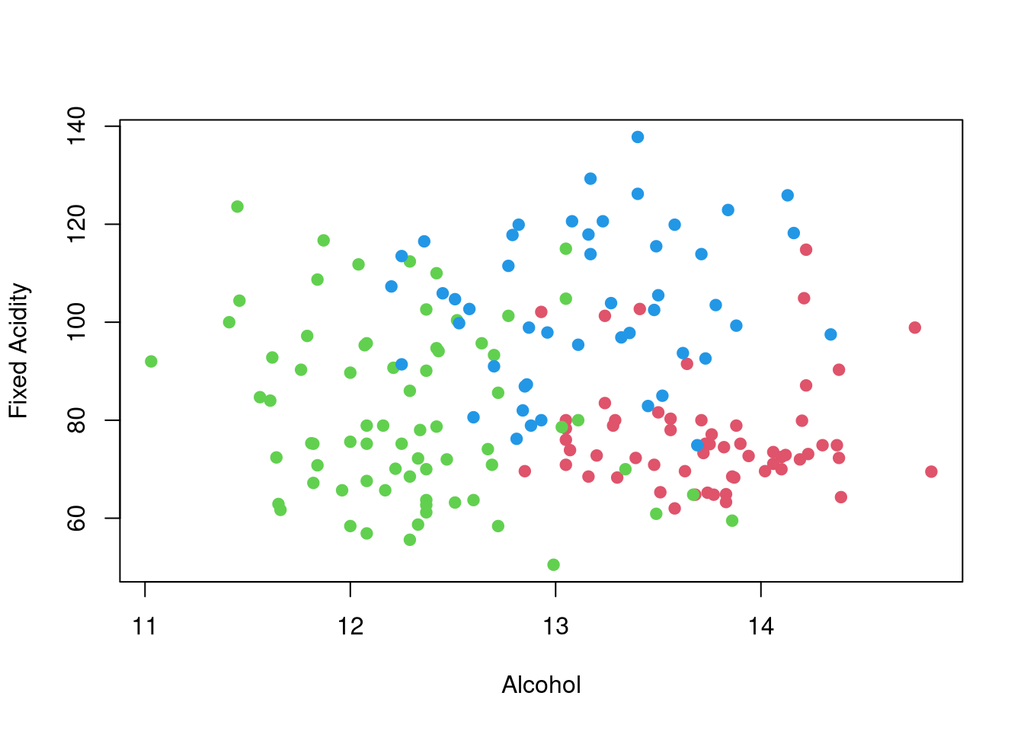

```r
plot(X, col = y+1, pch=19)
```

#### 1.4. Train/Test Split

We split the dataset, 2/3 for training and 1/3 for testing.

```r
n = dim(X)[1]
min_n_clusters = length(unique(y))
max_n_clusters = 10

training_split = round(2/3*n,0)

randomized_indexes = sample(1:nrow(X))
randomized_X = X[randomized_indexes,]
randomized_y = y[randomized_indexes]

X_train = randomized_X[1:training_split,]
X_test = randomized_X[training_split:n,]
y_train = randomized_y[1:training_split]
y_test = randomized_y[training_split:n]
```

# 2 - Function declarations

#### 2.1. Generic functions

This code is reproduced from the class.

```r
log_gaussian_density <- function (x, mean, sigma) {
  ######
  #### Computes the log-density probability of a variable estimated to follow
  #### a gaussian distribution.
  ######
  distval <- mahalanobis(x, center = mean, cov = sigma)
  logdet <- determinant(sigma,logarithm = TRUE)$modulus
  loglikelihood <- -(ncol(x) * log(2 * pi) + logdet + distval)/2
  # return statement
  return(loglikelihood)
}

logSumExp <- function (x) {
  ######
  #### Computes the log-sum-exponential of a vector, list of variables.
  ######
  y = max(x)
  y + log(sum(exp(x - y)))
}

logNorm <- function (x) {
  ######
  #### Log-normalizes a vector, list of variables.
  ######
  logratio = log(x) - logsumexp(log(x))
  exp(logratio)
}
```

#### 2.2. Expectation-Maximization algorithm

```r
logGamma <- function(n, clusters, x, prop, mu, sigma) {
  ######
  #### Precomputes the log-value of gamma as part of the EM algorithm.
  ######

  # Computes the gammas per clusters
    lgn = matrix(nrow=n, ncol=clusters)
    for (cl in 1:clusters){
      lgn[,cl] = log(prop[cl]) + matrix(dmvnorm(x, mu[cl,], sigma[[cl]], log=TRUE))
    }

    # return statement
    return(lgn)
}

mostMatchingDistribution <- function(clusters, x, prop, mu, sigma){
  ######
  #### Given a set of points, find the most matching distribution for them.
  #### to be used for a test set.
  ######

  # Computes the likelihood of belonging to a distribution
  likelihoods = logGamma(dim(x)[1], clusters, x, prop, mu, sigma)
  distributions = findCluster(likelihoods)

  # return statement
  return(list("likelihoods" = likelihoods, "distributions" = distributions))
}

findCluster <- function(likelihoods) {
  ######
  #### Given an array of likelihood with each column representing the
  #### likelihood of belonging to a specific cluster, finds the most
  #### matching cluster.
  ######

  # Computes the distribution to which each point belongs
  distributions = (likelihoods == apply(likelihoods, 1, max))
  distributions = apply(distributions, 1, which)

  # Return statement
  return(distributions)
}

expectationMaximization <- function(x, clusters, maxIterations=50) {
  ######
  #### Implementation of an Expectation Maximization algorithm for multivariate
  #### data, here the wine dataset provided by the pgmm library.
  ######

  # Variable declarations and initializations
  n = dim(x)[1]
  K = dim(x)[2]
  prop = rep(1/clusters, clusters)
  mu = rmvnorm(clusters, colMeans(x), cov(x))
  sigma = lapply(1:clusters, function(i) cov(x))

  # Algorithm loop
  for (loop in 1:maxIterations){

    #### Expectation step
    # Computes the new gamma values
    gam = logGamma(n, clusters, x, prop, mu, sigma)
    # Normalizes the gamma rows
    gam = gam - apply(gam, 1, logSumExp)
    gam = exp(gam)

    #### Maximization step
    for (cl in 1:clusters) {
      nk = sum(gam[,cl])
      # Parameter updates
      prop[cl] = nk/n
      mu[cl,] <- Reduce("+", lapply(1:n, function(i) gam[i,cl]*x[i,]))/nk
      sigma[[cl]] <- Reduce(
        "+",
        lapply(1:n,function(i) gam[i,cl]*(x[i,]-mu[cl,])%*%t(x[i,]-mu[cl,]))
        )/nk
    }
  }

  # Computes the llh results for the given data
  llh_results = mostMatchingDistribution(clusters, x, prop, mu, sigma)

  # return statement
  ret = list(
    "n_wines" = n,
    "n_clusters" = clusters,
    "cl_gamma" = gam,
    "cl_proportions" = prop,
    "cl_means" = mu,
    "cl_sigma" = sigma,
    "distributions" = llh_results$distributions,
    "logLikelihoods" = llh_results$likelihoods,
    "sum_of_llh" = sum(llh_results$likelihoods)
    )
  return(ret)
}
```

#### 2.3. K-Means Algorithm

```r
generateCentroid <- function(x) {
  ######
  #### Generates a random centroid from a given dataset.
  ######

  # Variable declarations and initializations
  K = dim(x)[2]
  centroid = c()

  # Randomly draws a value for each dimension of the dataset
  centroid = rmvnorm(1, colMeans(x), cov(x))
  colnames(centroid) <- NULL

  # return statement
  return(centroid)
}

euclidianDistance <- function(x, centroid){
  ######
  #### Computes the euclidian distance between a datapoint and a centroid.
  ######

  # Function declaration
  dist = function(x, y) (x-y)^2

  # Computes the distances
  distances = t(apply(x, 1,
                      function(i) sqrt(sum(mapply(dist, i, centroid))))
                )

  # Return statement
  return(distances)
}

findClosestCentroids <- function(x, centroids, clusters){
  ######
  #### Computes the closest centroids for a given set of datapoints.
  ######

  # Variable declarations and initializations
  n = dim(x)[1]
  K = dim(x)[2]

  # Computes the distances
  distances = c()
  for (cl in 1:clusters){
    cluster_dist = euclidianDistance(x, centroids[cl,])
    distances = append(distances, cluster_dist)
  }
  distances = array(distances, dim=c(n, clusters))

  # Finds the closest centroids
  closest = (distances == apply(distances, 1, min))

  # Return statement
  return(list("distances"=distances, "closest"=closest))

}

kMeans <- function(x, clusters, maxIterations=50) {
  ######
  #### Implementation of a K-Means algorithm for multivariate data, here
  #### the wine dataset provided by the pgmm library.
  ######

  # Variable declarations and initializations
  n = dim(x)[1]
  K = dim(x)[2]
  centroids = t(lapply(1:clusters, function(i) generateCentroid(x)))
  centroids = matrix(unlist(centroids), ncol=K, byrow=TRUE)

  # Computes the euclidian distances between every point and each centroid
  for (loop in 1:maxIterations){

    # Computes the closest centroids
    closest_centroids = findClosestCentroids(x, centroids, clusters)

    # Computes the new closest centroids
    centroids = c()
    for (cl in 1:clusters) {
      centroids = rbind(centroids, colMeans(x[closest_centroids$closest[,cl],]))
    }

    # Erases the matrix's columns and rows names inherited from the dataset
    colnames(centroids) <- NULL
    rownames(centroids) <- NULL
  }

  #return statement
  ret = list(
    "centroids" = centroids,
    "distances" = closest_centroids$distances,
    "closest_centroids" = apply(closest_centroids$closest, 1, which)
   )
  return(ret)
}
```

#### 2.4. Akaike Information Criterion

```r
akaikeIC <- function(logLikelihood, clusters, K) {
  ######
  #### Implementation of the the Akaike Information Criterion such that:
  #### AIC = LLH - eta(M)
  #### i.e. the final log-likelihood of a model minus the number of free
  #### scalar parameters in the model (nb of proportions (-1 as there are
  #### only cluster-1 degrees of freedom) + nb of means + nb of sigmas)
  ######
  penalization = (clusters-1) + clusters*K + clusters*((K*(K+1))/2)
  return(logLikelihood - penalization)
}

computeAIC <- function(x, max_cluster=max_n_clusters, print_steps=TRUE){
  ######
  #### Computes the AIC of an EM algorithm implementation given a dataset
  ######

  # Variable declaration
  akaike_results = c()

  # Loops through each cluster parameter to compute the corresponding AIC
  for (j in min_n_clusters:max_cluster){
    res = expectationMaximization(x, clusters=j)
    akaike_value = akaikeIC(res$sum_of_llh, j, dim(x)[2])
    akaike_results = append(akaike_results, akaike_value)
    if (print_steps) {
      print(paste("Total log-likelihood with ", j, " clusters: ",
                  round(akaike_value, 3)))
    }
  }

  # Prints the result
  print(paste("The best result is achieved with ",
              which.max(akaike_results)+2,
              " clusters (AIC)."))
}
```

#### 2.5. Bayesian Information Criterion

```r
bayesianIC <- function(logLikelihood, clusters, n, K) {
  ######
  #### Implementation of the Bayesian Information Criterion such that:
  #### BIC = LLH - 1/2*eta(M)*log(n)
  #### i.e. the final log-likelihood of a model minus the half of the number
  #### of free scalar parameters in the model (nb of proportions (-1 as there
  #### are only cluster-1 degrees of freedom) + nb of means + nb of sigmas)
  #### then multiplied by the log of the number of datapoints
  ######

  # Variable declaration
  penalization = (clusters-1) + clusters*K + clusters*((K*(K+1))/2)
  return(logLikelihood - 1/2 * penalization * log(n))
}

computeBIC <- function(x, max_cluster=max_n_clusters, print_steps=TRUE){
  ######
  #### Computes the BIC of an EM algorithm implementation given a dataset
  ######

  # Variable declaration
  bayesian_results = c()

  # Loops through each cluster parameter to compute the corresponding AIC
  for (j in min_n_clusters:max_cluster){
    res = expectationMaximization(x, clusters=j)
    bayesian_value = bayesianIC(res$sum_of_llh, j, dim(x)[1], dim(x)[2])
    bayesian_results = append(bayesian_results, bayesian_value)
    if (print_steps) {
      print(paste("Total log-likelihood with ", j, " clusters: ",
                  round(bayesian_value, 3)))
    }
  }

  # Prints the result
  print(paste("The best result is achieved with ",
              which.max(bayesian_results)+2,
              " clusters (BIC)."))
}
```

#### 2.6. (Cross-)Validated Likelihood

```r
doubleCrossValidation <- function(x_train, x_test, folds=10, max_cluster=max_n_clusters) {
  ######
  #### Implements a double cross-validation with the resulting log-likelihood
  #### being the selection criteria.
  ######

  # Variable declaration
  n_train = dim(x_train)[1]
  fold_indexes = split(c(1:n_train),
                       ceiling(seq_along(c(1:n_train))/(n_train/10)))
  mean_cluster_criteria = c()

  # iterates over the cluster range
  for (cl in min_n_clusters:max_cluster){
    # Performs the first step of the double cross-validation: iteration over the
    # folds of the training set
    llhs = c()
    best_model = NULL
    for (kFold in fold_indexes){
      x_train_train = x_train[-kFold,]
      x_train_val = x_train[kFold,]
      resultsEM = expectationMaximization(x_train_train, cl)
      matching_distribution = mostMatchingDistribution(
        resultsEM$n_clusters,
        x_train_val,
        resultsEM$cl_proportions,
        resultsEM$cl_means,
        resultsEM$cl_sigma
        )
      # Records the resulting log-likelihood
      sum_of_llhs = sum(matching_distribution$likelihoods)
      llhs = append(llhs, sum_of_llhs)
      if (is.null(best_model) || sum_of_llhs == min(llhs)){
        best_model <- resultsEM
      }
    }

    # Computes the likelihood on the test set given the best achieved model
    matching_distribution = mostMatchingDistribution(
        best_model$n_clusters,
        x_test,
        best_model$cl_proportions,
        best_model$cl_means,
        best_model$cl_sigma
        )
    llhs = append(llhs, sum(matching_distribution$likelihoods))

    # Records the mean llhs achieved with the cluster
    print(paste("Mean log-likelihood achieved with ", cl, " clusters: ",
                round(mean(llhs),4)))
    mean_cluster_criteria = append(mean_cluster_criteria, mean(llhs))
  }

  # Finds which cluster had the best performance
  best_cluster = which.max(mean_cluster_criteria)
  print(paste("The best result is achieved with ",
            best_cluster+2,
            " clusters (double CV)."))
  # return statement
  return(mean_cluster_criteria)

}
```

# 3 - Comparing EM and K-Means

#### 3.1.1. Computing the results (Full Dataset)

We compute our results with the EM and K-Means algorithms on the full dataset.

```r
n_clusters = 3

resultsEM = expectationMaximization(X, n_clusters)
resultsKM = kMeans(X, n_clusters)
```

We display the final clustering for the EM algorithm:

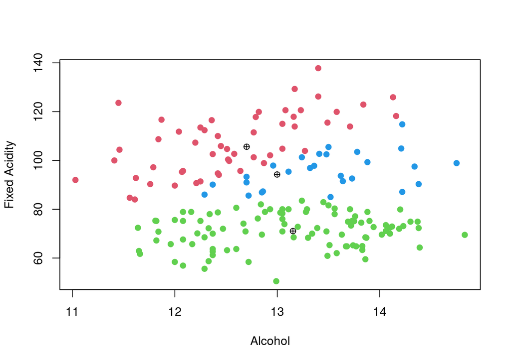

```r
plot(X, col=resultsEM$distributions+1, pch=19)
points(resultsEM$cl_means, col=1, pch=10)
```

We display the final clustering for the K-Means algorithm:

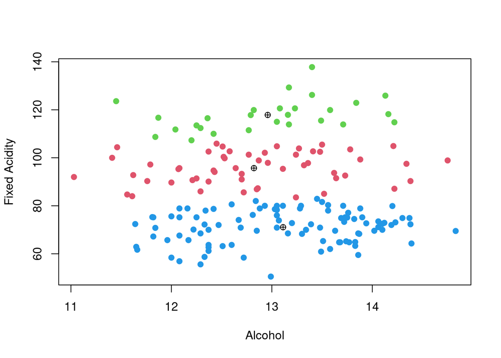

```r
plot(X, col=resultsKM$closest_centroids + 1, pch=19)
points(resultsKM$centroids, col=1, pch=10)
```

#### 3.1.2. Computing the results (Train-Test Split)

We compute our results with the EM and K-Means algorithms on the training set.

```r
resultsEM_train = expectationMaximization(X_train, n_clusters)
resultsKM_train = kMeans(X_train, n_clusters)
```

Then we test our clustering results on the test dataset.

```r
test_resultsEM = mostMatchingDistribution(
  n_clusters,
  X_test,
  resultsEM_train$cl_proportions,
  resultsEM_train$cl_means,
  resultsEM_train$cl_sigma
  )

test_resultsKM = findClosestCentroids(
  X_test,
  resultsKM_train$centroids,
  n_clusters
  )

test_resultsKM$closest = apply(test_resultsKM$closest, 1, which)
```

We display the final clustering for the EM algorithm:

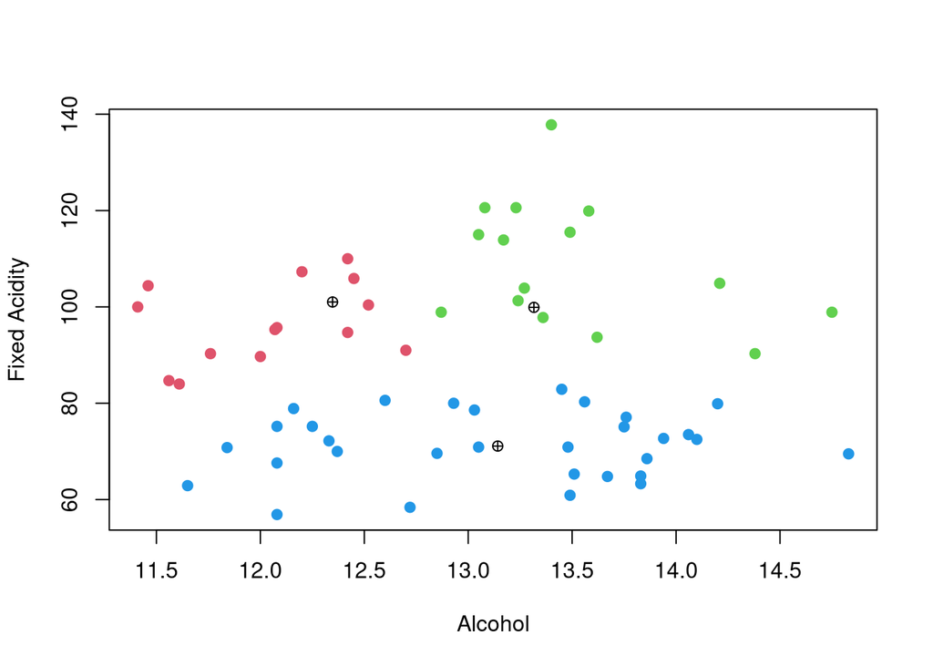

```r
plot(X_test, col=test_resultsEM$distributions+1, pch=19)
points(resultsEM_train$cl_means, col=1, pch=10)
```

We display the final clustering for the K-Means algorithm:

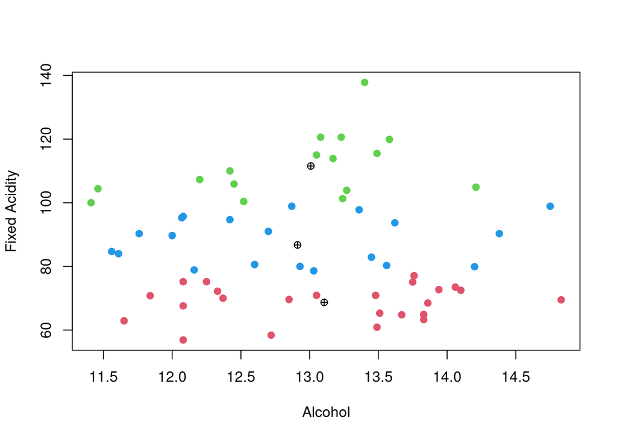

```r
plot(X_test, col=test_resultsKM$closest+1, pch=19)
points(resultsKM_train$centroids, col=1, pch=10)
```

Relying on the **mclust** library, we compute the classError and adjustedRandIndex to assess the quality of our clustering.

#### 3.2.1 Classification Error when clustering the whole dataset

Relying on the **mclust** library, we compute the [classError](https://mclust-org.github.io/mclust/reference/classError.html) to assess the quality of our clustering. The **Classification Error** corresponds to the rate of a given classification relative to the known classes, and the location of misclassified data points. I.e. Lower the better.

Expectation-Maximization:

```r
classError(resultsEM$distributions, y)
```

```
## $misclassified
##  [1]  14  20  22  40  42  44  46  47  57  60  61  63  64  65  66  67  68  69  71
## [20]  72  73  74  75  76  77  79  80  81  82  83  85  86  87  88  89  90  91  92
## [39]  93  94  96  97  98  99 101 102 103 104 105 106 107 108 109 117 132 133 135
## [58] 136 137 138 139 140 141 145 146 148 150 152 154 155 156 157 158 161 162 167
## [77] 168 169 170 171 172 173 174 175 176 177 178
##
## $errorRate
## [1] 0.488764
```

K-Means:

```r
classError(resultsKM$closest_centroid, y)
```

```
## $misclassified
##  [1]   5  14  20  22  40  42  44  46  47  57  61  63  64  65  66  67  68  69  71
## [20]  72  73  74  75  76  77  78  79  81  82  83  85  86  87  88  89  90  91  92
## [39]  93  96  97  98  99 100 101 102 103 104 105 106 107 109 117 121 123 124 125
## [58] 130 131 132 133 134 135 136 137 138 140 141 142 143 144 147 148 149 151 153
## [77] 155 158 159 160 162 163 164 165 166 167 176
##
## $errorRate
## [1] 0.488764
```

#### 3.2.2 Classification Error when clustering the test set (after training)

Expectation-Maximization:

```r
classError(test_resultsEM$distributions, y_test)
```

```
## $misclassified
##  [1]  1  4  5  6  7 10 12 16 27 28 29 30 38 40 42 43 44 45 50 51 52 54 55 57
##
## $errorRate
## [1] 0.4
```

K-Means:

```r
classError(test_resultsKM$closest, y_test)
```

```
## $misclassified
##  [1]  1  4  5  6  7 10 12 13 14 16 19 22 23 25 28 29 30 38 39 40 42 43 44 45 48
## [26] 52 54 56 57
##
## $errorRate
## [1] 0.4833333
```

#### 3.3.1. Adjusted Rand Index when clustering the whole dataset

Relying on the **mclust** library, we compute the [Adjusted Rand Index](https://mclust-org.github.io/mclust/reference/adjustedRandIndex.html) to assess the quality of our clustering. The **Adjusted Rand Index** compares two partitions of values with a resulting score between 0 and 1, with zero indicating randomness between the two and 1 indicating a perfect match. I.e. Higher the better.

Expectation-Maximization:

```r
adjustedRandIndex(resultsEM$distributions, y)
```

```
## [1] 0.1789447
```

K-Means:

```r
adjustedRandIndex(resultsKM$closest_centroid, y)
```

```
## [1] 0.1492959
```

#### 3.3.2. Adjusted Rand Index when clustering the test set (after training)

Expectation-Maximization:

```r
adjustedRandIndex(test_resultsEM$distributions, y_test)
```

```
## [1] 0.1833073
```

K-Means:

```r
adjustedRandIndex(test_resultsKM$closest, y_test)
```

```
## [1] 0.1204972
```

#### 3.4. Comments and observations

When re-knitting/running the R markdown, it happens that, *in general*, the EM algorithm performs better than the K-Means (rarely, the reverse happens, which seems to be tied to the initialization of the centroids/parameters).

Sometimes, the K-Means ends up splitting the data points vertically rather than horizontally (this case results in the K-Means performing better than the EM algorithm.)

# 4 - Performing Model Selection with the EM algorithm

Starting with a cluster number of 3, we increase the number and check with different heuristics and criteria to select our best EM model.

#### 4.1. Using the Akaike Information Criterion

```r
computeAIC(X)
```

```
## [1] "Total log-likelihood with  3  clusters:  -7054.353"
## [1] "Total log-likelihood with  4  clusters:  -9208.622"
## [1] "Total log-likelihood with  5  clusters:  -11137.82"
## [1] "Total log-likelihood with  6  clusters:  -17107.348"
## [1] "Total log-likelihood with  7  clusters:  -25733.579"
## [1] "Total log-likelihood with  8  clusters:  -225845.188"
## [1] "Total log-likelihood with  9  clusters:  -29522.803"
## [1] "Total log-likelihood with  10  clusters:  -39638.281"
## [1] "The best result is achieved with  3  clusters (AIC)."
```

#### 4.2. Using the Bayesian Information Criterion

```r
computeBIC(X)
```

```
## [1] "Total log-likelihood with  3  clusters:  -5719.807"
## [1] "Total log-likelihood with  4  clusters:  -7975.47"
## [1] "Total log-likelihood with  5  clusters:  -11383.371"
## [1] "Total log-likelihood with  6  clusters:  -211062.904"
## [1] "Total log-likelihood with  7  clusters:  -19153.68"
## [1] "Total log-likelihood with  8  clusters:  -19346.758"
## [1] "Total log-likelihood with  9  clusters:  -36780.385"
## [1] "Total log-likelihood with  10  clusters:  -265369.027"
## [1] "The best result is achieved with  3  clusters (BIC)."
```

#### 4.3. Using Cross-Validated Likelihood

We implement a double cross-validation with 10 folds and a maximum cluster parameter of 10.

```r
cv_logLikelihoods = doubleCrossValidation(X_train, X_test)
```

```
## [1] "Mean log-likelihood achieved with  3  clusters:  -675.847"
## [1] "Mean log-likelihood achieved with  4  clusters:  -1234.7991"
## [1] "Mean log-likelihood achieved with  5  clusters:  -4475.0062"
## [1] "Mean log-likelihood achieved with  6  clusters:  -2236.5093"
## [1] "Mean log-likelihood achieved with  7  clusters:  -950497.2791"
## [1] "Mean log-likelihood achieved with  8  clusters:  -10123.4429"
## [1] "Mean log-likelihood achieved with  9  clusters:  -58168686.1657"
## [1] "Mean log-likelihood achieved with  10  clusters:  -33779.0476"
## [1] "The best result is achieved with  3  clusters (double CV)."
```

#### 4.4. Comments and observations

# 5 - Testing with higher-dimensional spaces

#### 5.1. Hand-selected features

We decide to select the first 3 features in this first hand-selected testing of the EM algorithm with a high-dimensional dataset.

```r
Xhd = as.matrix(wine[,c(2:4)])
```

We compute the best cluster number for the dataset using the BIC.

```r
computeBIC(Xhd)
```

```
## [1] "Total log-likelihood with  3  clusters:  -7261.764"
## [1] "Total log-likelihood with  4  clusters:  -10978.198"
## [1] "Total log-likelihood with  5  clusters:  -102218.519"
## [1] "Total log-likelihood with  6  clusters:  -20905.036"
## [1] "Total log-likelihood with  7  clusters:  -61182.248"
## [1] "Total log-likelihood with  8  clusters:  -157897.755"
## [1] "Total log-likelihood with  9  clusters:  -144692942.241"
## [1] "Total log-likelihood with  10  clusters:  -273591.108"
## [1] "The best result is achieved with  3  clusters (BIC)."
```

We find that the best results are obtained using 3 clusters with the high-dimensional dataset. Based on this, we try to apply the EM algorithm on a train split of the dataset and try to check the resulting clustering on a test dataset.

```r
# we reuse the randomized indexes computed in 1.4
randomized_Xhd = Xhd[randomized_indexes,]
randomized_yhd = y[randomized_indexes]
Xhd_train = randomized_Xhd[1:training_split,]
Xhd_test = randomized_Xhd[training_split:n,]
yhd_train = randomized_yhd[1:training_split]
yhd_test = randomized_yhd[training_split:n]

resultsEMhd_train = expectationMaximization(Xhd_train, 3)

test_resultsEMhd = mostMatchingDistribution(
  3,
  Xhd_test,
  resultsEMhd_train$cl_proportions,
  resultsEMhd_train$cl_means,
  resultsEMhd_train$cl_sigma
  )
```

Once done with the processing, we can visualize the resulting clustering on the test set by focusing on the two features we started with in this exercise:

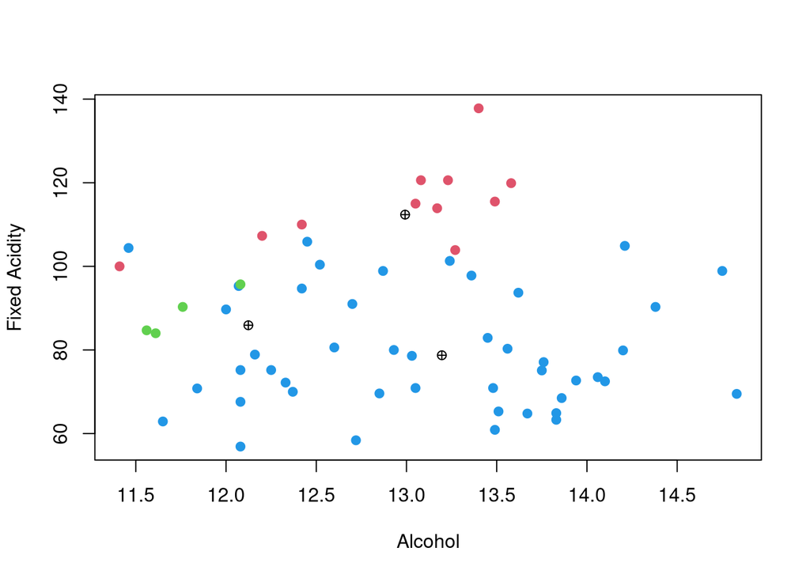

```r
plot(Xhd_test[,c(1,3)], col=test_resultsEMhd$distributions+1, pch=19); points(resultsEMhd_train$cl_means[,c(1,3)], col=1, pch=10)
```

Class Error:

```r
classError(test_resultsEMhd$distributions, y_test)
```

```
## $misclassified
##  [1]  4  6  7 10 12 13 14 15 16 17 19 23 25 27 28 29 30 38 39 40 42 43 44 45 47
## [26] 48 51 52 55
##
## $errorRate
## [1] 0.4833333
```

Adjusted Rand Index:

```r
adjustedRandIndex(test_resultsEM$distributions, y_test)
```

```
## [1] 0.1833073
```

Comments and observations:

Going through multiple trials of the EM algorithm, we find that the clustering is less consistent when we use more dimension of the data. Sometimes, two clusters out of three (the best number of clusters found via AIC, BIC, and CV) will gobble the third, making the clustering on the test set rather unreliable.

#### 5.2.1. Randomly selected features

To test a number of different higher-dimension sets of features, we generate five 5-elements permutations allowed by the dataset (out of 27 feature columns). From this set of 5-permutations, we build the corresponding sets of 3-, and 4- sub-permutations.

As such, the selection of permutations would look something like:

- (a,b,c,d,e), (a,b,c,d), (a,b,c,e), (a,c,d,e), …, (b,c,d), (c,d,e)

i.e. 5 5-permutations, 600 4-permutations, 14400 3-permutations.

Given this high number of permutations, we only randomly select 20 permutations out of the 4- and 3- permutations sets respectively.

```r
# We extract the features from the original dataset
wine_features = subset(wine, select=-c(Type))

# We produce 5 5-permutations by random sampling
five_perms = c()
for (p in 1:5) {
  five_perms = rbind(five_perms, sample(colnames(wine_features), 5))
}

# We produce the set of 4-permutations
four_perms = NULL
for (p in 1:nrow(five_perms)) {
  all <- expand.grid(p1 = five_perms[p,],
                     p2 = five_perms[p,],
                     p3 = five_perms[p,],
                     p4 = five_perms[p,],
                     stringsAsFactors = FALSE)
  perms <- all[apply(all, 1, function(x) {length(unique(x)) == 4}),]
  if (is.null(four_perms)) {
    four_perms = perms
  } else {
    four_perms = rbind(four_perms, perms)
  }
}
four_perms = as.matrix(four_perms)

# We produce the set of 3-permutations
three_perms = NULL
for (p in 1:nrow(four_perms)) {
  all <- expand.grid(p1 = four_perms[p,],
                     p2 = four_perms[p,],
                     p3 = four_perms[p,],
                     stringsAsFactors = FALSE)
  perms <- all[apply(all, 1, function(x) {length(unique(x)) == 3}),]
  if (is.null(three_perms)) {
    three_perms = perms
  } else {
    three_perms = rbind(three_perms, perms)
  }
}
three_perms = as.matrix(three_perms)
```

We remove the duplicated permutations:

```r
five_perms = five_perms[!duplicated(apply(five_perms, 1, sort)),]
four_perms = four_perms[!duplicated(apply(four_perms, 1, sort)),]
three_perms = three_perms[!duplicated(apply(three_perms, 1, sort)),]
```

#### 5.2.2. Computing the AIC and BIC for the 5-permutations

We compute the best number of clusters via the use of the AIC and BIC with the following features of the wine dataset.

```r
for (perm in 1:nrow(five_perms)) {
  cat("\nSelected features: ", paste(five_perms[perm,], collapse=", "), "\n")
  computeAIC(as.matrix(wine_features[five_perms[perm,]]), print_steps=FALSE)
}
```

```
##
## Selected features:  Uronic Acids, OD280/OD315 of Flavanoids, Hue, Glycerol, Non-flavanoid Phenols
## [1] "The best result is achieved with  3  clusters (AIC)."
##
## Selected features:  Hue, Total Phenols, Alcalinity of Ash, Ash, Malic Acid
## [1] "The best result is achieved with  3  clusters (AIC)."
##
## Selected features:  Alcalinity of Ash, Proline, Potassium, Malic Acid, Proanthocyanins
## [1] "The best result is achieved with  3  clusters (AIC)."
##
## Selected features:  2-3-Butanediol, Sugar-free Extract, Malic Acid, Magnesium, Phosphate
## [1] "The best result is achieved with  3  clusters (AIC)."
##
## Selected features:  Hue, Uronic Acids, Sugar-free Extract, pH, Non-flavanoid Phenols
## [1] "The best result is achieved with  3  clusters (AIC)."
```

```r
for (perm in 1:nrow(five_perms)) {
  cat("\nSelected features: ", paste(five_perms[perm,], collapse=", "), "\n")
  computeBIC(as.matrix(wine_features[five_perms[perm,]]), print_steps=FALSE)
}
```

```
##
## Selected features:  Uronic Acids, OD280/OD315 of Flavanoids, Hue, Glycerol, Non-flavanoid Phenols
## [1] "The best result is achieved with  3  clusters (BIC)."
##
## Selected features:  Hue, Total Phenols, Alcalinity of Ash, Ash, Malic Acid
## [1] "The best result is achieved with  4  clusters (BIC)."
##
## Selected features:  Alcalinity of Ash, Proline, Potassium, Malic Acid, Proanthocyanins
## [1] "The best result is achieved with  3  clusters (BIC)."
##
## Selected features:  2-3-Butanediol, Sugar-free Extract, Malic Acid, Magnesium, Phosphate
## [1] "The best result is achieved with  3  clusters (BIC)."
##
## Selected features:  Hue, Uronic Acids, Sugar-free Extract, pH, Non-flavanoid Phenols
## [1] "The best result is achieved with  4  clusters (BIC)."
```

#### 5.2.3. Computing the AIC for the 4-permutations

```r
for (perm in sample(1:nrow(four_perms), 20)) {
  cat("\nSelected features: ", paste(four_perms[perm,], collapse=", "), "\n")
  computeAIC(as.matrix(wine_features[four_perms[perm,]]), print_steps=FALSE)
}
```

```
##
## Selected features:  Hue, Non-flavanoid Phenols, Sugar-free Extract, pH
## [1] "The best result is achieved with  3  clusters (AIC)."
##
## Selected features:  Potassium, Alcalinity of Ash, Malic Acid, Proline
## [1] "The best result is achieved with  3  clusters (AIC)."
##
## Selected features:  Hue, Glycerol, Uronic Acids, Non-flavanoid Phenols
## [1] "The best result is achieved with  3  clusters (AIC)."
##
## Selected features:  Hue, Sugar-free Extract, Uronic Acids, Non-flavanoid Phenols
## [1] "The best result is achieved with  4  clusters (AIC)."
##
## Selected features:  Hue, OD280/OD315 of Flavanoids, Glycerol, Uronic Acids
## [1] "The best result is achieved with  3  clusters (AIC)."
##
## Selected features:  Sugar-free Extract, Non-flavanoid Phenols, Uronic Acids, Hue
## [1] "The best result is achieved with  3  clusters (AIC)."
##
## Selected features:  Hue, Total Phenols, Alcalinity of Ash, Malic Acid
## [1] "The best result is achieved with  3  clusters (AIC)."
##
## Selected features:  Sugar-free Extract, Magnesium, 2-3-Butanediol, Malic Acid
## [1] "The best result is achieved with  3  clusters (AIC)."
##
## Selected features:  Malic Acid, Potassium, Proanthocyanins, Proline
## [1] "The best result is achieved with  3  clusters (AIC)."
##
## Selected features:  Magnesium, 2-3-Butanediol, Sugar-free Extract, Malic Acid
## [1] "The best result is achieved with  3  clusters (AIC)."
##
## Selected features:  Hue, Malic Acid, Total Phenols, Ash
## [1] "The best result is achieved with  4  clusters (AIC)."
##
## Selected features:  Proanthocyanins, Proline, Potassium, Alcalinity of Ash
## [1] "The best result is achieved with  3  clusters (AIC)."
##
## Selected features:  Ash, Alcalinity of Ash, Hue, Total Phenols
## [1] "The best result is achieved with  3  clusters (AIC)."
##
## Selected features:  Sugar-free Extract, Phosphate, Malic Acid, 2-3-Butanediol
## [1] "The best result is achieved with  3  clusters (AIC)."
##
## Selected features:  Non-flavanoid Phenols, Uronic Acids, Glycerol, Hue
## [1] "The best result is achieved with  4  clusters (AIC)."
##
## Selected features:  Phosphate, 2-3-Butanediol, Magnesium, Sugar-free Extract
## [1] "The best result is achieved with  3  clusters (AIC)."
##
## Selected features:  Malic Acid, Proanthocyanins, Potassium, Alcalinity of Ash
## [1] "The best result is achieved with  3  clusters (AIC)."
##
## Selected features:  Hue, Non-flavanoid Phenols, Uronic Acids, pH
## [1] "The best result is achieved with  7  clusters (AIC)."
##
## Selected features:  Ash, Alcalinity of Ash, Total Phenols, Malic Acid
## [1] "The best result is achieved with  4  clusters (AIC)."
##
## Selected features:  2-3-Butanediol, Sugar-free Extract, Magnesium, Malic Acid
## [1] "The best result is achieved with  5  clusters (AIC)."
```

#### 5.2.4. Computing the AIC for the 3-permutations

```r
for (perm in sample(1:nrow(three_perms), 20)) {
  cat("\nSelected features: ", paste(three_perms[perm,], collapse=", "), "\n")
  computeAIC(as.matrix(wine_features[three_perms[perm,]]), print_steps=FALSE)
}
```

```
##
## Selected features:  OD280/OD315 of Flavanoids, Glycerol, Non-flavanoid Phenols
## [1] "The best result is achieved with  3  clusters (AIC)."
##
## Selected features:  pH, Hue, Uronic Acids
## [1] "The best result is achieved with  3  clusters (AIC)."
##
## Selected features:  Non-flavanoid Phenols, Glycerol, Hue
## [1] "The best result is achieved with  3  clusters (AIC)."
##
## Selected features:  Uronic Acids, Hue, Glycerol
## [1] "The best result is achieved with  4  clusters (AIC)."
##
## Selected features:  Malic Acid, Ash, Hue
## [1] "The best result is achieved with  3  clusters (AIC)."
##
## Selected features:  Sugar-free Extract, pH, Non-flavanoid Phenols
## [1] "The best result is achieved with  3  clusters (AIC)."
##
## Selected features:  Sugar-free Extract, pH, Non-flavanoid Phenols
## [1] "The best result is achieved with  3  clusters (AIC)."
##
## Selected features:  Proanthocyanins, Potassium, Malic Acid
## [1] "The best result is achieved with  3  clusters (AIC)."
##
## Selected features:  Proanthocyanins, Alcalinity of Ash, Malic Acid
## [1] "The best result is achieved with  3  clusters (AIC)."
##
## Selected features:  Non-flavanoid Phenols, Hue, pH
## [1] "The best result is achieved with  3  clusters (AIC)."
##
## Selected features:  Uronic Acids, Hue, Non-flavanoid Phenols
## [1] "The best result is achieved with  3  clusters (AIC)."
##
## Selected features:  Malic Acid, Hue, Ash
## [1] "The best result is achieved with  4  clusters (AIC)."
##
## Selected features:  Proanthocyanins, Malic Acid, Proline
## [1] "The best result is achieved with  3  clusters (AIC)."
##
## Selected features:  Proanthocyanins, Alcalinity of Ash, Proline
## [1] "The best result is achieved with  3  clusters (AIC)."
##
## Selected features:  pH, Non-flavanoid Phenols, Hue
## [1] "The best result is achieved with  3  clusters (AIC)."
##
## Selected features:  Ash, Malic Acid, Hue
## [1] "The best result is achieved with  3  clusters (AIC)."
##
## Selected features:  Ash, Alcalinity of Ash, Malic Acid
## [1] "The best result is achieved with  3  clusters (AIC)."
##
## Selected features:  Phosphate, Sugar-free Extract, Malic Acid
## [1] "The best result is achieved with  3  clusters (AIC)."
##
## Selected features:  Phosphate, 2-3-Butanediol, Sugar-free Extract
## [1] "The best result is achieved with  3  clusters (AIC)."
##
## Selected features:  Non-flavanoid Phenols, Glycerol, Hue
## [1] "The best result is achieved with  3  clusters (AIC)."
```